# Handling and Analyzing Spatial, Spatiotemporal and Movement Data

Edzer Pebesma

22 June, 2016

The source R-Markdown (.Rmd) file for this document is found [here](https://raw.githubusercontent.com/edzer/UseR2016/master/tutorial.Rmd)

# Introduction

Two quotes from [Cobb and Moore, 1997](http://www.jstor.org/stable/2975286),

> *Data are not just numbers, they are numbers with a context*

and

> *in data analysis, context provides meaning*

illustrate that data analysis without context is essentially meaningless. What is context? We can think of

- *who* collected or generated the data,
- *how* were the data collected (e.g., by which sampling strategy?),
- for which purpose were the data collected, or generated (*why*)
- *when* and *where* were the data collected
- *what* exactly was collected, what do the values refer to, what are measurement units, and what does the value `1` refer to?

We can think of the *who, how* and *why* question referring to pragmatics of data collection, where *when, where* and *what* refer to data semantics.

## Time in R

Base R has some infrastructure to annotate measurement units, in particular for time and date information:

```r
now = Sys.time() + c(0, 3600)
today = Sys.Date() + 0:1
```

which represent numeric values pointing to the number of seconds or days elapsed since Jan 1, 1970, 00:00 UTC:

```r
as.numeric(now)
```

```
## [1] 1466620165 1466623765
```

```r
as.numeric(today)
```

```
## [1] 16974 16975
```

The `class` attribute of these objects

```r
class(now)
```

```
## [1] "POSIXct" "POSIXt"
```

```r
class(today)
```

```
## [1] "Date"
```

make it behave meaningfully like time:

```r
now * now
```

```
## Error in Ops.POSIXt(now, now): '*' not defined for "POSIXt" objects
```

```r
now + now
```

```
## Error in `+.POSIXt`(now, now): binary '+' is not defined for "POSIXt" objects
```

```r
(dt = now[2] - now[1])
```

```
## Time difference of 1 hours
```

## Time differences

This last quantity, `dt` has a class

```r
class(dt)
```

```
## [1] "difftime"
```

but also a `units` attribute, which can be retrieved by the `units` method:

```r
units(dt)
```

```
## [1] "hours"
```

but can also be set to other values, e.g.

```r
units(dt) = "days"
dt
```

```
## Time difference of 0.04166667 days
```

```r
units(dt) = "secs"
dt
```

```
## Time difference of 3600 secs
```

## Measurement units

Beyond time and time differences, more general support for [SI units](https://en.wikipedia.org/wiki/International_System_of_Units) and derived units is provided by CRAN package units, which builds upon CRAN package udunits2 and the external [udunits](https://www.unidata.ucar.edu/software/udunits/) library, from [UNIDATA](https://www.unidata.ucar.edu/). It checks compatibility of units, does unit conversion on the fly

```r
library(units)
x = as.units(1:3, "m/s")
xkmh = x
units(xkmh) = "km/h"        # explicit conversion
xkmh
```

```
## Units: km/h
## [1]  3.6  7.2 10.8
```

```r
(y = as.units(1:3, "km/h")) # something different
```

```
## Units: km/h
## [1] 1 2 3
```

```r
x + y                       # implicit conversions
```

```
## Units: m/s
## [1] 1.277778 2.555556 3.833333
```

```r
y + x
```

```
## Units: km/h
## [1]  4.6  9.2 13.8
```

```r
c(x, y)
```

```
## Units: m/s
## [1] 1.0000000 2.0000000 3.0000000 0.2777778 0.5555556 0.8333333
```

it creates derived units where appropriate

```r
x * y
```

```
## Units: (m/s)*(km/h)
## [1] 1 4 9
```

```r
x / y
```

```
## Units: (m/s)/(km/h)
## [1] 1 1 1
```

```r
log(x)
```

```
## Units: ln(m/s)
## [1] 0.0000000 0.6931472 1.0986123
```

and also gives meaningful warnings when units are not compatible:

```r
x + x * y
```

```
## Error in `units<-.units`(`*tmp*`, value = "m/s"): cannot convert (m/s)*(km/h) into m/s
```

as udunits parses units, they can become arbitrarily complex:

```r
u1 = paste0(rep("m", 100), collapse = "*")
u2 = "m^100"
as.units(1:3, u2) + as.units(1:3, u1)
```

```
## Units: m^100
## [1] 2 4 6
```

units nicely integrates with `data.frame` objects and even better with dplyr:

```r
library(dplyr)
x = filter(mtcars, cyl == 8)
(x1 <- x %>% mutate(mpg = as.units(mpg, "miles/gallon")) %>% head(2))
```

```
##                 mpg cyl disp  hp drat   wt  qsec vs am gear carb
## 1 18.7 miles/gallon   8  360 175 3.15 3.44 17.02  0  0    3    2
## 2 14.3 miles/gallon   8  360 245 3.21 3.57 15.84  0  0    3    4
```

```r
x1 %>% mutate(kmpl = as.units(mpg, "km/l")) %>% tbl_df %>% select(c(1, 12))
```

```
## Source: local data frame [2 x 2]
##
##                 mpg          kmpl
##              (unts)        (unts)
## 1 18.7 miles/gallon 7.950187 km/l
## 2 14.3 miles/gallon 6.079555 km/l
```

Summarizing, measurement units

- convert units explicitly, or implicitly/on the fly
- catch operations that are algebraically correct but *physically meaningless*
- help carry out [dimensional analysis](https://en.wikipedia.org/wiki/Dimensional_analysis)

and provide, in that sense, part of the context of data.

## Why don’t we treat space and time as special cases of SI units?

Measures of physical quantities such as length, mass, duration have a natural, absolute zero value. When measuring absolute time (when) and location (where), we need a reference.

For time, we have Coordinated Universal Time ([UTC](https://en.wikipedia.org/wiki/Coordinated_Universal_Time)); different time zones and DST rules are defined with respect to UTC.

For space, different [geodetic datums](https://en.wikipedia.org/wiki/Geodetic_datum) exist; the best known being the [WGS84](https://en.wikipedia.org/wiki/World_Geodetic_System) ellipsoid (``world geodetic system-1984’’)

WGS84 is a *global* reference system, and has larger errors (deviations from the geoid, the `mean sea level’ surface) than ellipsoids that are fitted locally. For that reason, local ellipsoids might better fit the Earth locally, and are prefered for particular surveying projects. Coordinate *transformations* move from one geodetic datum (ellispoid) to another; these transformation may be non-unique, non-invertible, and approximate.

Projecting longitude/latitude degrees to a flat representation (such as UTM, or Web Mercator) is called coodinate *conversion*; this process is usually accurate and invertible.

## When are space and time *not* relevant?

For a doctor, the identity and age of the patient are more relevant than the location of the patient and date of the examination. An MRI scan of a patient’s brain is understood *with reference to* the skull and other reference points, not with reference to the geographical location f the MRI scanner.

Many data sets come without information about space and time; this usually indicates that these aspects were not considered relevant. For the `co2` dataset,

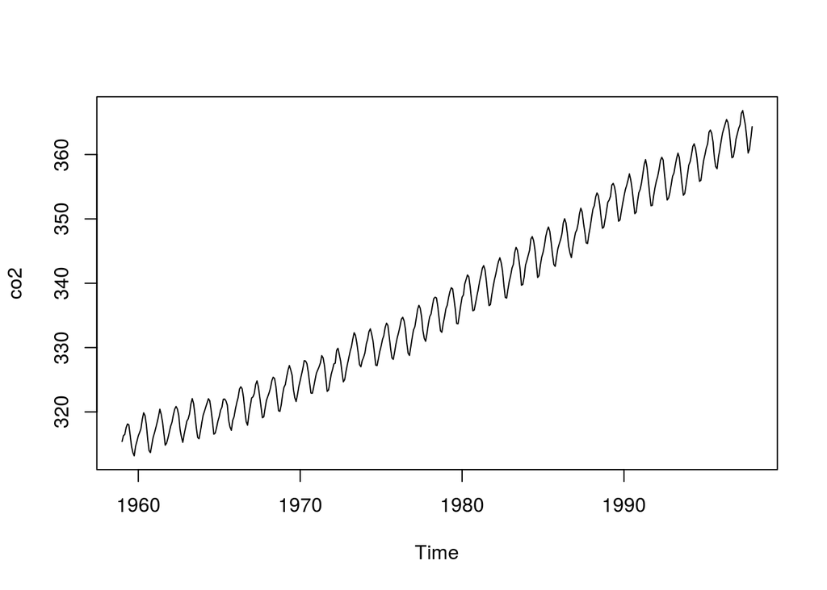

```r
plot(co2)
```

the location of measurements ([Mauna Loa](https://en.wikipedia.org/wiki/Mauna_Loa)) can be derived from the URL mentioned in `?co2`, or even better, from the information the URL points to. For the `mtcars` dataset, `?mtcars` reveals when the car models described were current (1973-4).

# Time series data

We have seen so far mostly time information, but not information that is associated with time, or *time series data*.

## Classes for time series data

The `co2` data set is an example of this, as a time series:

```r
class(co2)
```

```
## [1] "ts"
```

```r
summary(co2)
```

```
##    Min. 1st Qu.  Median    Mean 3rd Qu.    Max.
##   313.2   323.5   335.2   337.1   350.3   366.8
```

The `ts` class, part of base R, accomodates for regular time series, and does not use `POSIXt` for time:

```r
attributes(co2)
```

```
## $tsp
## [1] 1959.000 1997.917   12.000
##
## $class
## [1] "ts"
```

Many of the methods for `ts` do not deal well with semi-regular time series, which are regular but contain missing values.

Approaches to deal with irregular time series are found in packages its, zoo and xts. Package xts builds on `POSIXt` as the time index, and extends `zoo`. The combination has nice features for

- selection, supporting [ISO 8601](https://en.wikipedia.org/wiki/ISO_8601) strings for time periods
- aggregation, using functions that cut time in particular intervals

```r
data(air, package = "spacetime")
library(zoo)
library(xts)
```

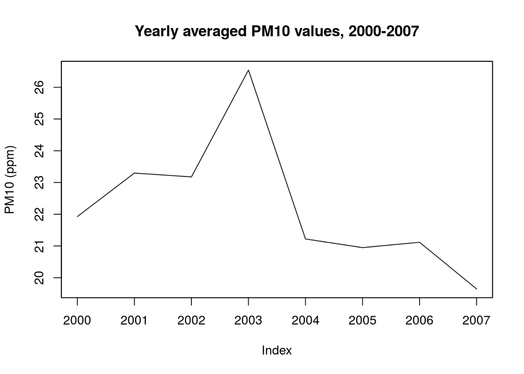

```r
pm10 = xts(t(air), dates)
as.year <- function(x) as.numeric(floor(as.yearmon(x)))
plot(aggregate(pm10["2000::2007", 1], as.year, mean, na.rm = TRUE),
    ylab = "PM10 (ppm)")
title("Yearly averaged PM10 values, 2000-2007")
```

## Extensive or intensive properties?

Physical properties can be [extensive or intensive](https://en.wikipedia.org/wiki/Intensive_and_extensive_properties), depending on whether the property changes when the size (extent) of the system changes:

- exptensive properties are for instance mass and size: if we cut a rock into pieces, mass and size of a piece change
- intensive properties are e.g. temperature or density; these do not necessarily change with size

In the aggregation example above, we computed the yearly *mean* values, but when examining `?aggregate.zoo`, we’d find out that the default aggregation function is `sum`, so

```r
a = aggregate(pm10["2000::2007", 1], as.year, na.rm = TRUE)
mean(a)
```

```
## [1] 7176.552
```

## Events, continuous series, aggregations?

Time series data, as represented by the packages mentioned above, do not distinguish events from continuous processes: ``values’’ of something are simply associated with a time stamp. Yet, for meaningful analysis, their difference could not be larger:

- for events, we can compute counts, or densities over time, but we cannot interpolate; for instance, the temporally interpolated value of earthquake magnitudes for a moment with no earthquake does not make sense
- for continuous processes, counts or densities only reveal properties of the sampling procedure, and not of the observed phenomenon (which could have been observed any moment)

Many time series data (`co2` and `pm10` above being two examples) concern temporally aggregated values. Yet, their value is not explicitly registered with the aggregation period, but rather with the starting time of this interval. If, however, instantaneous measurements of the same variables would be available (co2 or pm10 measured at the start of the month), they would be stored identically. If time periods would be registered explicitly, we would in addition have to specify how the associated (co2, pm10) value relates to this interval, possibilities are:

- the value is constant throughout this interval
- the value was aggregated over this interval (in which case the aggregation *function* needs to be specified)

# Spatial data

## Classes for spatial data

A large majority of spatial data constitute, roughly, of points, lines, polygons or grids. As described in [Bivand, Pebesma and Gomez-Rubio (2013)](http://asdar-book.org/), package sp provides basic infrastructure for this, and supports the following classes:

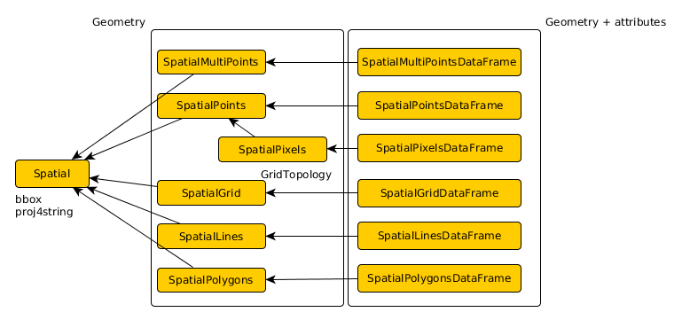

The geometry-only classes, `SpatialXxx`, derive from `Spatial` and share a bounding box and coordinate reference system (`proj4string`); all the `SpatialXxxDataFrame` classes extend this with a `data.frame` carrying attributes associated with the geometries.

Important reasons why many think that using `sp` is a good idea include:

- reinventing the wheel too often creates duplicate work, and calls for many-to-many conversions
- through rgdal, `sp` supports reading and writing to and from all 142 [raster](http://gdal.org/formats_list.html) and 84 [vector](http://gdal.org/ogr_formats.html) formats supported by [GDAL](http://www.gdal.org/)
- through rgeos, `sp` objects can be used for all DE-9IM intersections, including topological predicates like *touches*, *overlaps*, *intersects*, *contains*, etc., and also create buffers, unite polygons etc.

## An example: why polygons are complex

`Single’ geometry entries for polygons and lines can consist of multiple polygons or lines, to accomodate real-word data. In the following example we see a state consisting of multiple polygons, one of them containing a hole:

```r
data(air, package = "spacetime")
library(sp)
nds = DE_NUTS1["Niedersachsen",]
library(ggmap)
bgMap = get_map(as.vector(bbox(nds)), source = "google", zoom = 7)
```

```
## converting bounding box to center/zoom specification. (experimental)
```

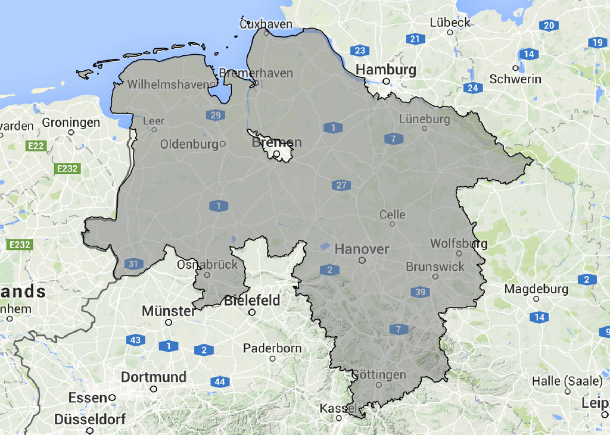

```r
par(mar = rep(0,4))
merc = CRS("+init=epsg:3857")
plot(spTransform(nds, merc), bgMap = bgMap, col = grey(.5, alpha = .5))
```

We can examine the data interactively, thanks to the excellent mapview package:

```r
library(mapview)
mapview(nds)
```

[interactive chart not shown]

When properly plotting data, we need to know which hole polygon belongs to which enclosing polygon, and this makes it difficult (if not impossible) to encode polygons in simple tables such as propagated by the [tidy data](https://www.jstatsoft.org/article/view/v059i10) framework. The `fortify` method in `ggplot2` destroys this structure, and the [ggplot2 wiki](https://github.com/hadley/ggplot2/wiki/plotting-polygon-shapefiles) explains why `ggplot2` cannot properly plot polygons with holes.

In the plot above, we can see that the border of `nds` does not correspond very well with that of [openstreetmap](http://www.openstreetmap.org/). This may be due to an outdated version of `DE_NUTS1` in the `spacetime` package.

### Exercise

1. visit [gadm](http://gadm.org/)
2. download the German administrative boundaries as a shapefile from gadm.org
3. unzip the files starting with `DEU_adm1`, and register in which directory they are
4. read them in with `library(rgdal); x = readOGR(".", "DEU_adm1")`, where you replace `.` with the right directory
5. plot Lower Saxony with mapview (`mapview(x[9,])`)
6. check whether the Dutch/German boundaries are better, now.

## Selecting features

As we’ve seen above, we can use `[` on `Spatial` objects to select geometries/features (``rows''), or particular attributes, similar to how this is done for`data.frame`objects. Further functionality is obtained when we use a`Spatial` object as selector, as in

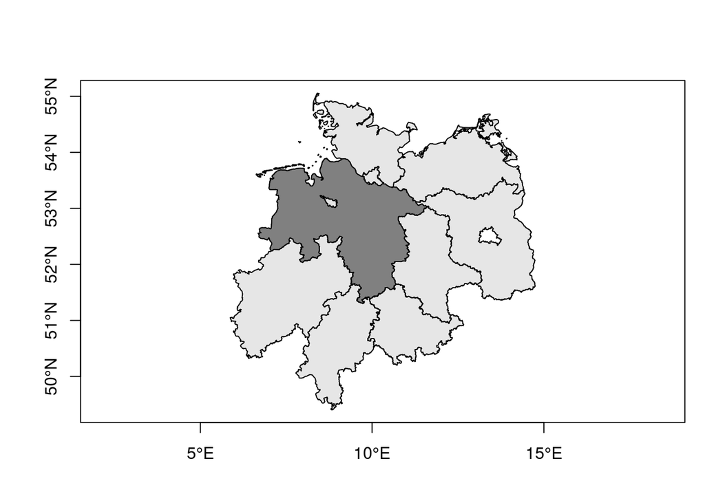

```r
par(mar = c(4,4,4,1))
plot(DE_NUTS1[nds,], col = grey(.9), axes = TRUE) # all states touching Lower Saxony;
plot(nds, col = grey(.5), add = TRUE) # .. which is grey.
```

this carries out an intersection, and returns intersecting geometries, for *any Spatial object type*.

# Spatiotemporal data

# Importing spatial and temporal data

## from tables

## form shapefiles

## from web services

# Spatial data classes in sp

# Spatiotemporal data in spacetime

# Trajectory data in trajectories

## plotting

## aggregation

- import spatial, temporal, and spatiotemporal data in R
- map these data structures to and from matrix and data.frame objects
- work with time series of each of these
- work with space-time events, and moving objects
- intersect various spacetime objects, e.g. for spatial and/or temporal selection or for spatial, temporal or spatiotemporal aggregation
- represent higher concepts such as fields, objects, events, trajectories, and aggregations into the classes, and how to carry out meaningful analysis of these